# Thesis Project

# Model Testing:

## XGBoost 1:

- This first XGBoost model aims to be a lighter weight model, only selecting 10 variables from the dataset. Additionally, I only created two lag features and recoded my categorical rural_urban column as numeric

```r
library(tidyverse)
library(xgboost)
library(caret)
data <- read.csv("C:\\Users\\jashb\\OneDrive\\Documents\\Masters Data Science\\Spring 2025\\DATA 698\\Masters Project\\final_data.csv")

df <- data %>%
  select(year, fips, county.x, percent_food_insecure,
    percent_unemployed, percent_children_in_poverty,
    median_household_income, percent_fair_or_poor_health,
    high_school_graduation_rate, rural_urban
  ) %>%
  drop_na(percent_food_insecure)  #just making sure there are no na's left in for this XGBoost model
```

### Create Lag Features and code rural_urban on

- Using a standard 1 and 2 year lag variable for the entire model

```r
df <- df %>%
  arrange(fips, year) %>%
  group_by(fips) %>%
  mutate(
    food_insecure_lag1 = lag(percent_food_insecure, 1),  # Previous year
    food_insecure_lag2 = lag(percent_food_insecure, 2)   # Two years back
  ) %>%
  ungroup()

# recode rural_urban as numeric
df <- df %>%
  mutate(rural_urban = as.factor(rural_urban),
         rural_urban = as.numeric(rural_urban))
```

### Split Data

```r
train <- df %>% filter(year < 2024)
test <- df %>% filter(year == 2024)

# dropping out the non-important features, including the dependent variable
X_train <- train %>% select(-c(year, fips, county.x, percent_food_insecure))
y_train <- train$percent_food_insecure

X_test <- test %>% select(-c(year, fips, county.x, percent_food_insecure))
y_test <- test$percent_food_insecure
```

### Experiment 1: Train Model

```r
# cross val
ctrl <- trainControl(
  method = "cv",
  number = 10,
  verboseIter = TRUE
)

# Standard xgboost tuning grid
xgb_grid <- expand.grid(
  nrounds = 100,
  max_depth = 6,
  eta = 0.3,
  gamma = 0,
  colsample_bytree = 1,
  min_child_weight = 1,
  subsample = 1
)


xgb_model <- train(
  x = X_train,
  y = y_train,
  method = "xgbTree",
  trControl = ctrl,
  tuneGrid = xgb_grid,
  verbosity = 0
)
print(xgb_model)
```

```
## eXtreme Gradient Boosting
##
## 252 samples
##   8 predictor
##
## No pre-processing
## Resampling: Cross-Validated (10 fold)
## Summary of sample sizes: 226, 227, 228, 227, 228, 226, ...
## Resampling results:
##
##   RMSE       Rsquared  MAE
##   0.9396357  0.782687  0.7290635
##
## Tuning parameter 'nrounds' was held constant at a value of 100
## Tuning
##  held constant at a value of 1
## Tuning parameter 'subsample' was held
##  constant at a value of 1
```

### Apply Experiment 1 Model:

```r
# predicting 2024 data
X_2024 <- df %>%
  filter(year == 2024) %>%
  select(-c(year, fips, county.x, percent_food_insecure))

# Predicting 2024 food insecurity
predictions_2024 <- predict(xgb_model, newdata = X_2024)

# bringing in county and fips codes
results <- df %>%
  filter(year == 2024) %>%
  select(fips, county.x) %>%
  mutate(pred_2024_food_insecure = predictions_2024)

# View predictions
print(results)
```

```
## # A tibble: 63 × 3
##     fips county.x    pred_2024_food_insecure
##    <int> <chr>                         <dbl>
##  1 36000 Total                         10.0
##  2 36001 Albany                         9.34
##  3 36003 Allegany                      13.1
##  4 36005 Bronx                         17.9
##  5 36007 Broome                        12.3
##  6 36009 Cattaraugus                   12.7
##  7 36011 Cayuga                        10.5
##  8 36013 Chautauqua                    13.2
##  9 36015 Chemung                       11.9
## 10 36017 Chenango                      10.6
## # ℹ 53 more rows
```

### Experiment 1: Predicted vs Actual Food Insecurity

```r
# Predict 2024 (for validPrediPredir)
pred_2024 <- predict(xgb_model, newdata = X_test)

# Calculate RMSE
rmse <- sqrt(mean((pred_2024 - y_test)^2))
print(paste("RMSE:", rmse))
```

```
## [1] "RMSE: 1.07624761613868"
```

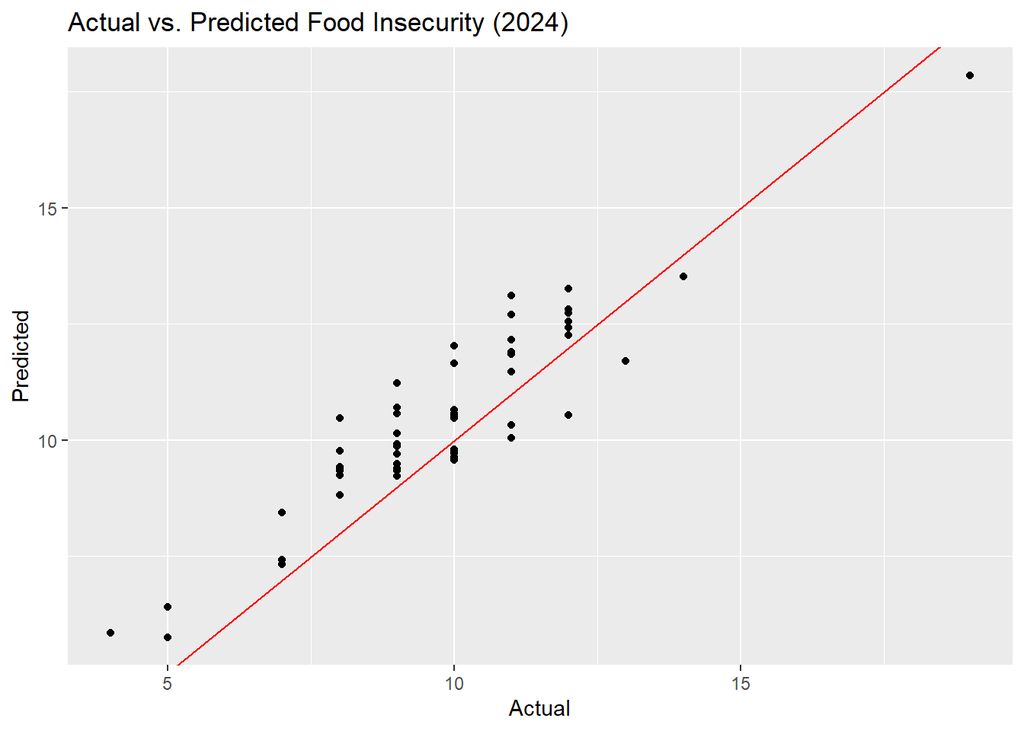

```r
ggplot(data.frame(Actual = y_test, Predicted = pred_2024), aes(Actual, Predicted)) +
  geom_point() +
  geom_abline(slope = 1, intercept = 0, color = "red") +
  labs(title = "Actual vs. Predicted Food Insecurity (2024)")
```

### Experiment 1 Data Metrics Table

```r
library(caret)
library(Metrics)
```

```r
test_predictions <- predict(xgb_model, newdata = X_test)
actual_values <- y_test

metrics_table <- data.frame(
  RMSE = RMSE(test_predictions, actual_values),
  MAPE = mape(actual_values, test_predictions) * 100,
  MSE = mean((test_predictions - actual_values)^2),
  R2 = R2(test_predictions, actual_values)
)

print(metrics_table)
```

```
##       RMSE    MAPE      MSE        R2
## 1 1.076248 10.3129 1.158309 0.8556726
```

## XGBoost 2:

- XGBoost model 2 brings in a few different changes to the model, the lag variables are still created but this time the model is tuned to be faster.
- By dropping the number of folds from 10 to 5 this should cut the number of boosted models ran for this experiment.

```r
library(tidyverse)
library(xgboost)
library(caret)


data <- read.csv("C:\\Users\\jashb\\OneDrive\\Documents\\Masters Data Science\\Spring 2025\\DATA 698\\Masters Project\\final_data.csv")


df <- data %>%
  select(where(~ all(!is.na(.)))) %>%
  drop_na(percent_food_insecure)
```

```r
df <- df %>%
  arrange(fips, year) %>%
  group_by(fips) %>%
  mutate(
    food_insecure_lag1 = lag(percent_food_insecure, 1),  # Previous year
    food_insecure_lag2 = lag(percent_food_insecure, 2)   # Two years back
  ) %>%
  select(-food_environment_index) %>%
  ungroup()


df <- df %>%
  mutate(rural_urban = as.factor(rural_urban),
         rural_urban = as.numeric(rural_urban))
```

```r
train <- df %>% filter(year < 2024)
test <- df %>% filter(year == 2024)


X_train <- train %>% select(-c(year, fips, county.x, percent_food_insecure, state.x))
y_train <- train$percent_food_insecure

X_test <- test %>% select(-c(year, fips, county.x, percent_food_insecure, state.x))
y_test <- test$percent_food_insecure
```

```r
ctrl_fast <- trainControl(
  method = "cv",
  number = 5,  # Reduced from 10 folds
  verboseIter = TRUE,
  allowParallel = TRUE  # Enable parallel processing
)

# Tuning grid set
xgb_grid_fast <- expand.grid(
  nrounds = c(100, 150, 200, 300),          # Reduced options
  max_depth = c(4, 6, 8),            # Most useful range
  eta = c(0.05, 0.1, .15),            # Optimal learning rates
  gamma = 0,
  colsample_bytree = 0.8,
  min_child_weight = 1,
  subsample = 0.8
)

# Parallel processing to speed things up
library(doParallel)
cl <- makePSOCKcluster(4)
registerDoParallel(cl)

xgb_fast <- train(
  x = X_train,
  y = y_train,
  method = "xgbTree",
  trControl = ctrl_fast,
  tuneGrid = xgb_grid_fast,
  verbosity = 0,
  metric = "RMSE"
)
```

```
## Fitting nrounds = 300, max_depth = 4, eta = 0.05, gamma = 0, colsample_bytree = 0.8, min_child_weight = 1, subsample = 0.8 on full training set
```

```r
stopCluster(cl)


print(xgb_fast)
```

```
## eXtreme Gradient Boosting
##
## 252 samples
##  13 predictor
##
## No pre-processing
## Resampling: Cross-Validated (5 fold)
## Summary of sample sizes: 201, 202, 201, 202, 202
## Resampling results across tuning parameters:
##
##   eta   max_depth  nrounds  RMSE       Rsquared   MAE
##   0.05  4          100      0.8781404  0.8355296  0.6707104
##   0.05  4          150      0.8540096  0.8402291  0.6462976
##   0.05  4          200      0.8453597  0.8426345  0.6345746
##   0.05  4          300      0.8451813  0.8424344  0.6312022
##   0.05  6          100      0.8923034  0.8322891  0.6678132
##   0.05  6          150      0.8754636  0.8340372  0.6504066
##   0.05  6          200      0.8773633  0.8331453  0.6492893
##   0.05  6          300      0.8772838  0.8334252  0.6496573
##   0.05  8          100      0.8974352  0.8291845  0.6731898
##   0.05  8          150      0.8816944  0.8291804  0.6630502
##   0.05  8          200      0.8796597  0.8293649  0.6624847
##   0.05  8          300      0.8796704  0.8292728  0.6624413
##   0.10  4          100      0.8648257  0.8364921  0.6439529
##   0.10  4          150      0.8642269  0.8362099  0.6417462
##   0.10  4          200      0.8645774  0.8362313  0.6412801
##   0.10  4          300      0.8656470  0.8356974  0.6410426
##   0.10  6          100      0.8825171  0.8286300  0.6591104
##   0.10  6          150      0.8806580  0.8292312  0.6567807
##   0.10  6          200      0.8797769  0.8296094  0.6567192
##   0.10  6          300      0.8796946  0.8296352  0.6566413
##   0.10  8          100      0.8979305  0.8253533  0.6732380
##   0.10  8          150      0.8972889  0.8256395  0.6722391
##   0.10  8          200      0.8970448  0.8257292  0.6718342
##   0.10  8          300      0.8970231  0.8257341  0.6718000
##   0.15  4          100      0.8607434  0.8359365  0.6525811
##   0.15  4          150      0.8637856  0.8354407  0.6524942
##   0.15  4          200      0.8638682  0.8354469  0.6534405
##   0.15  4          300      0.8643632  0.8352971  0.6540152
##   0.15  6          100      0.8865801  0.8275857  0.6848609
##   0.15  6          150      0.8874475  0.8272966  0.6852978
##   0.15  6          200      0.8874683  0.8272873  0.6853752
##   0.15  6          300      0.8874747  0.8272835  0.6853918
##   0.15  8          100      0.8980507  0.8237776  0.6916497
##   0.15  8          150      0.8981906  0.8237612  0.6917727
##   0.15  8          200      0.8981609  0.8237745  0.6917438
##   0.15  8          300      0.8981608  0.8237731  0.6917376
##
## Tuning parameter 'gamma' was held constant at a value of 0
## Tuning
##
## Tuning parameter 'min_child_weight' was held constant at a value of 1
##
## Tuning parameter 'subsample' was held constant at a value of 0.8
## RMSE was used to select the optimal model using the smallest value.
## The final values used for the model were nrounds = 300, max_depth = 4, eta
##  = 0.05, gamma = 0, colsample_bytree = 0.8, min_child_weight = 1 and
##  subsample = 0.8.
```

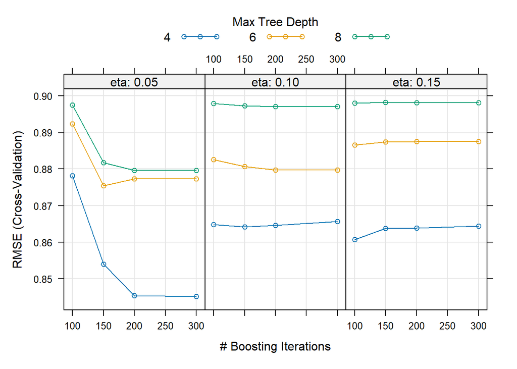

```r
plot(xgb_fast)
```

```r
library(doParallel)
library(Metrics)
cl <- makePSOCKcluster(4)
registerDoParallel(cl)


ctrl_fast <- trainControl(
  method = "cv",
  number = 5,  # Reduced from 10 folds
  verboseIter = TRUE,
  allowParallel = TRUE,  # Enable parallel processing
  savePredictions = "final"
)

xgb_grid_fast <- expand.grid(
  nrounds = c(100, 150, 200, 300),
  max_depth = c(4, 6, 8),
  eta = c(0.05, 0.1, 0.15),
  gamma = 0,
  colsample_bytree = 0.8,
  min_child_weight = 1,
  subsample = 0.8
)

# Train the  model
xgb_optimized <- train(
  x = X_train,
  y = y_train,
  method = "xgbTree",
  trControl = ctrl_fast,
  tuneGrid = xgb_grid_fast,
  verbosity = 0,
  metric = "RMSE"
)
```

```
## Fitting nrounds = 100, max_depth = 6, eta = 0.15, gamma = 0, colsample_bytree = 0.8, min_child_weight = 1, subsample = 0.8 on full training set
```

```r
stopCluster(cl)


print(xgb_optimized)
```

```
## eXtreme Gradient Boosting
##
## 252 samples
##  13 predictor
##
## No pre-processing
## Resampling: Cross-Validated (5 fold)
## Summary of sample sizes: 200, 201, 202, 203, 202
## Resampling results across tuning parameters:
##
##   eta   max_depth  nrounds  RMSE       Rsquared   MAE
##   0.05  4          100      0.9011120  0.8215231  0.6883451
##   0.05  4          150      0.8883722  0.8238125  0.6832788
##   0.05  4          200      0.8871622  0.8248628  0.6815495
##   0.05  4          300      0.8860341  0.8259349  0.6812098
##   0.05  6          100      0.8703363  0.8340119  0.6657812
##   0.05  6          150      0.8621970  0.8342835  0.6608138
##   0.05  6          200      0.8620012  0.8347651  0.6608094
##   0.05  6          300      0.8631944  0.8346652  0.6618495
##   0.05  8          100      0.9131806  0.8173697  0.7086733
##   0.05  8          150      0.9046190  0.8175442  0.7055069
##   0.05  8          200      0.9046224  0.8174260  0.7065193
##   0.05  8          300      0.9061115  0.8170087  0.7079110
##   0.10  4          100      0.8734851  0.8303399  0.6738947
##   0.10  4          150      0.8790684  0.8286507  0.6803869
##   0.10  4          200      0.8830418  0.8275311  0.6840421
##   0.10  4          300      0.8849291  0.8270416  0.6873362
##   0.10  6          100      0.9129718  0.8158589  0.7000536
##   0.10  6          150      0.9154483  0.8151201  0.7024064
##   0.10  6          200      0.9157415  0.8151300  0.7026213
##   0.10  6          300      0.9159481  0.8151109  0.7027467
##   0.10  8          100      0.8852688  0.8266064  0.6896946
##   0.10  8          150      0.8863866  0.8262701  0.6895852
##   0.10  8          200      0.8867005  0.8261605  0.6898820
##   0.10  8          300      0.8868083  0.8261222  0.6900218
##   0.15  4          100      0.9059950  0.8168906  0.7002083
##   0.15  4          150      0.9104842  0.8148878  0.7046985
##   0.15  4          200      0.9115235  0.8147664  0.7060750
##   0.15  4          300      0.9118689  0.8147551  0.7064888
##   0.15  6          100      0.8571253  0.8368995  0.6665441
##   0.15  6          150      0.8575728  0.8368456  0.6669733
##   0.15  6          200      0.8577060  0.8367976  0.6672284
##   0.15  6          300      0.8577302  0.8367929  0.6672692
##   0.15  8          100      0.8979386  0.8207182  0.7209347
##   0.15  8          150      0.8978211  0.8207909  0.7207613
##   0.15  8          200      0.8978151  0.8207947  0.7207717
##   0.15  8          300      0.8978187  0.8207937  0.7207718
##
## Tuning parameter 'gamma' was held constant at a value of 0
## Tuning
##
## Tuning parameter 'min_child_weight' was held constant at a value of 1
##
## Tuning parameter 'subsample' was held constant at a value of 0.8
## RMSE was used to select the optimal model using the smallest value.
## The final values used for the model were nrounds = 100, max_depth = 6, eta
##  = 0.15, gamma = 0, colsample_bytree = 0.8, min_child_weight = 1 and
##  subsample = 0.8.
```